# Selective pressures for phage tRNA acquisition

# 4 Results

## 4.1 Genomic analysis of phage and host reveals differences in genomic codon usage patterns

In order to dissect the selective advantages that tRNA carriage may convey, we used phage 2.275.O [NCBI:txid1881285] as a model. This phage is part of the Nahant Collection, an extensive collection of Vibriophage previously described by Kauffman, et al. (Kauffman 2014; Kauffman et al. 2018). At 348,911 bp, it is among the largest known bacteriophage (Figure 4.1), and it is capable of infecting hosts from at least two different species, *Vibrio cyclitrophicus* and *V. lentus*. And finally, its genome encodes for 18 tRNAs that correspond to 15 amino acids (missing are alanine, tryptophan, aspartic acid, histadine, and lysine), as well as another seven tRNA-like sequences with putative introns.

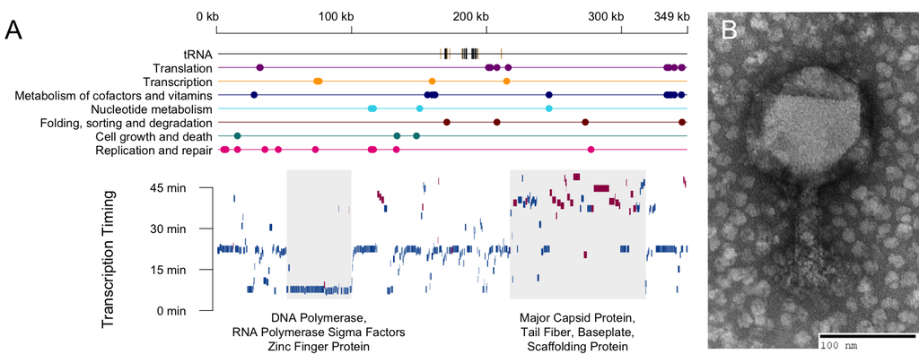

Figure 4.1: Phage 2.275.O carries 25 tRNA genes and is a large phage in both capsid size (120 nm) and genome size (348,911 bp). (A) Estimation of transcriptional units and their timing of expression. Top plot shows genome position of KEGG annotated genes, and bottom plot shows time to reach half the maximum expression of that gene (bottom). Blue and red bars indicate genes on the positive and negative strand, respectively. Early genes tend to be polymerases and sigma factors, while late genes tend to be structural proteins. More detailed annotations can be found in Supplementary Figure 1. (B) Electron microscopy image of phage 2.275.O.

To test whether the codon usage hypothesis is plausible, we first conducted preliminary analyses to verify that a codon usage difference between the phage and host exists. To this end, we applied multidimensional scaling (Figure 4.2a) and multinomial discriminant analysis (Figure 4.2b) to the codon usage for each gene from the genomes of the phage and its host of isolation. We observed that there is indeed a codon usage difference between the two organisms, allowing us to next ask, do the phage tRNA bias translation in the direction of this difference? Previously, tRNA copy number (Figure 4.3a) in the genomes of phage and their hosts was used to assess whether phage tRNAs may optimize codon usage differences (Bailly-Bechet, Vergassola, and Rocha 2007). And in examining the odds ratio for each codon in the phage vs. host genome (Figure 4.3b), the codons that can be recognized by an anticodon from a host tRNA (according to extended wobble rules summarized by dos Reis, et al. (Reis, Savva, and Wernisch 2004; Watanabe and Osawa 1995; Yokoyama and Nishimura 1995)) appears to be more commonly used by host genes than by phage genes. On the other hand, codons that can be recognized by both phage and host tRNAs span the range of usage preferences. Instead of selectively acquiring tRNAs that are more beneficial to it than its host, it appears the phage seeks to acquire diverse tRNAs, but places lower priority on those that benefit mainly its host.

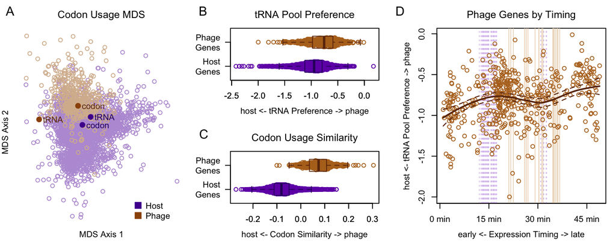

Figure 4.2: Codon usage bias introduced by the phage tRNA pool is more pronounced in late genes than early genes. (A) A multidimensional scaling (MDS) plot of phage and host genes using Shannon-Jensen Divergence of the codon distributions shows that codon usage difference between phage and host. Points representing the codon recognition capacities of the tRNA pool for each organism are overlaid. Points representing the average codon usage for each organism are also overlaid. The axes have been omitted, as, for an MDS plot, the main message is the relationship/distance of the points (phage or host genes) to each other. (B) Preference for the phage tRNA vs. the host tRNA pool (slant). (Zero signifies ambivalence.) (C) Mean codon usage for host and phage. (D) Slant toward the phage tRNA pool vs. timing of expression depicted as center of mass of RNA expression for the first round of infection. Note that this is different from the expression timing described in figure 1. The center of mass in this plot indicates how quickly the RNA transcript is degraded, while the time to half maximum expression shown in figure 1 summarizes transcription timing.

However, this analysis does not account for RNA modifications, which can often be found at the wobble base and may thus change tRNA specificity; and furthermore, tRNA expression level may be more relevant information for assessing any translational bias that may be introduced.

## 4.2 tRNA sequencing suggests that phage tRNA actively participate in translation

We are also able to infer putative addition of similar base modifications on the phage and host tRNAs. In our tRNA sequencing protocol, we used the group II intron reverse transcriptase TGIRT (Clark et al. 2016), which can read through RNA modifications but may leave DNA base substitution signatures evident as a multinomial mixture of A, C, G, T, and/or a decrease in read density downstream of the modification (Supplementary Figure 3). For example, in comparing one of the phage CAU tRNAs (Genbank genome location: 182648-18272) with a host CAU tRNA (Genbank locus tag: BCV12_11325), both are modified with 4-thiouridine on the 8th base, 3-(3-amino-3-carboxypropyl)uridine on the 47th base, and, importantly, 2-lysidine on the 34th base (Supplementary Figure 3), putatively changing them to AUA-recognizing isoleucine tRNA (Harada and Nishimura 1974). Other similar putative modifications can be observed between phage tRNA and their host analogs, for example, 5-carboxymethylaminomethyl-2-thiouridine on base 34 of Glutamine tRNA, 1-methylguanosine on base 37 of (most) Leucine tRNA (Supplementary Materials). These similarities suggest that phage tRNAs may be recognized and processed by the same enzymes as corresponding host tRNAs.

Interestingly, we also observed seven intron-containing tRNA-like sequences. These, while not recognized by tRNAscan-SE (Lowe and Eddy 1997), were recognized by another tRNA caller, Aragorn (Laslett and Canback 2004). These sequences are only expressed at levels as low as 0.003 times (as in the case of threonine tRNA) to 0.2 times (as in the case of serine tRNA) the abundance of an isoacceptor phage tRNA without an intron. Although a small fraction of the reads did appear to be spliced as called, many did not, and the aligned anticodon loop was fairly heterogeneous for these species. In addition, many of these sequences do not end in CCA and did not appear to receive CCA tails. These intron-containing tRNA-like sequences may serve non-canonical functions, and so were therefore not used beyond the initial preliminary analyses.

## 4.3 Codon usage bias is present but not pronounced

Having found evidence supporting the idea that the 18 phage tRNAs without introns likely participate in translation, we tested the most common hypothesis as to why phage carry tRNA - to increase the translational efficiency of their own genes over that of their hosts’ (Scherberg and Weiss 1972; Wilson 1973; Bailly-Bechet, Vergassola, and Rocha 2007; Enav, Béjà, and Mandel-Gutfreund 2012). For each gene, we calculated a value representing the efficiency with which it can be translated by the phage tRNA pool, relative to the efficiency with which it can be translated by the host tRNA pool (see Materials and Methods), for simplicity, we will refer to this value as the “slant” of a gene.

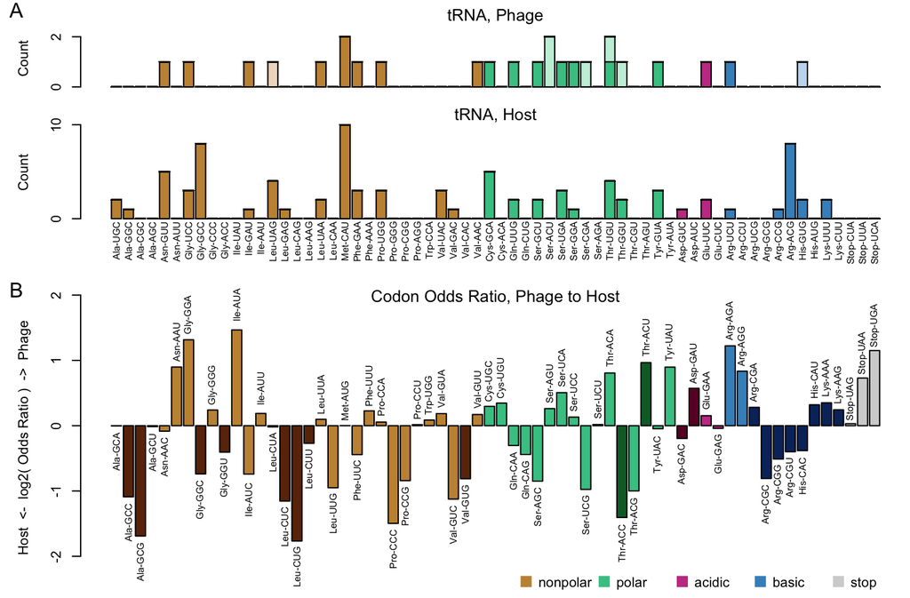

Figure 4.3: Analysis of the phage and host genome supports the codon usage hypothesis. (A) tRNA content in the genomes of the phage and host. Less saturated bars indicate putative tRNA with introns. (B) Differences between the codon usages of phage and host. Darker-hued bars indicate codons that cannot be recognized by phage tRNA, given the wobble rules summarized by **dos Reis, et al.**

We therefore instead asked whether the slant values for phage vs. host genes are different given the known difference in codon usage for the two organisms. Conditioning appropriately, the probability of seeing as high or a higher difference in slant between the phage proteins and host proteins in the direction of the phage tRNA pool was approximately 0.08. (See Materials and Methods for details of this calculation, as well as Supplementary Figure 4.) This probability is, at best, suggestive, but we cannot be confident that codon usage bias optimization has been the main factor driving tRNA acquisition.

We next calculated the codon usage profiles for other Vibrios in the Nahant Collection for which we have completely sequenced genomes, including Vibrio lentus and additional Vibrio cyclitrophicus strains that are known hosts of 2.275.O. As expected, we find that codon usage profiles cluster by species (Supplementary Figure 5, top panel). V. cyclitrophicus hosts are more similar in codon usage to 2.275.O than V. lentus hosts. (Supplementary Figure 5, bottom panel). As V. cyclitrophicus was the host of isolation, it is tempting to infer that V. cyclitrophicus might be a “preferred” host for 2.275.O; however we note that we cannot exhaustively identify all potential hosts for this phage.

## 4.4 Host genomic DNA and RNA degradation as the driving factor for tRNA acquisition

One potential explanation for the low overall signal for codon optimization is that only a subset of the phage genes is affected, in particular the late genes, as previously shown for T4 (Cowe and Sharp 1991). Codon usage optimization toward the late genes might be advantageous for a few reasons: (1) mRNAs from the earliest genes might already be undergoing translation and degradation as the phage tRNAs are transcribed, and therefore must utilize mainly the host tRNA pool; and (2) the host tRNA pool might degrade, in which case, translation, during the late stages of infection might heavily rely on phage tRNA.

Some evidence in the literature supports the latter hypothesis. During T4 infection of *E. coli*, degradation of host DNA is initiated by Endo II and Endo IV (Miller et al. 2003), in part to help supply the nucleotide pool for phage replication. This comes with a consequence: although tRNAs tend to be more stable than other RNAs (Davis, Luger, and Tai 1986), they can undergo rapid degradation under stress conditions (Zhong et al. 2015; Svenningsen et al. 2017). In fact, during T4 infection, *E. coli* uses nucleases to deplete its own lysine tRNA, dialing down translation, seemingly in defense while, as a “rebuttal,” T4 RNA ligase is able to repair damaged tRNA (Amitsur, Levitz, and Kaufmann 1987). Evidence for this all-destructive infection phenotype suggests that supplying translational components might help the phage to fill the growing gaps in host machinery and thereby prolong the replication period.

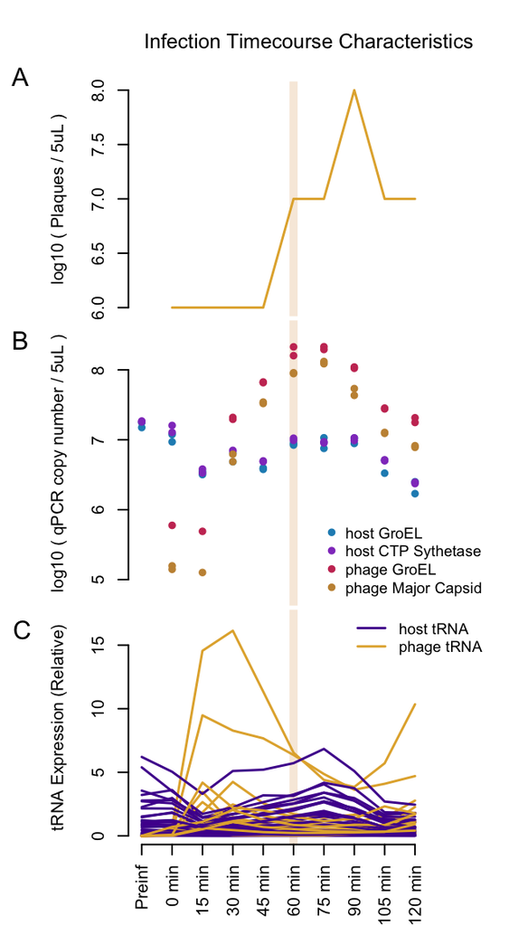

When examining the tRNA expression from transcriptome sequencing data, we found that the host tRNA were indeed degraded rapidly, reaching a minimum value around 15 minutes, whereas phage tRNA were continually produced (Figure 4.4C, see Supplementary Figure 7 for individual tracts of host and phage tRNA by amino acid). The increase in host RNA after 15 minutes is likely due to regrowth of uninfected cells in the culture. We note that the presence of uninfected cells in the culture renders it difficult to reliably infer the levels of host tRNA in infected cells.

These observations support the hypothesis that, as the host tRNA pool is degraded, the phage tRNA allow translation to be sustained; this may especially benefit the late genes, which do not reach half their maximum expression until 40–45 minutes into the infection (Figure 4.1).

Having found that the host genome and transcriptome (including the tRNA) were indeed degraded during infection, we next utilized the full transcriptome sequencing data to quantify 2.275.O gene expression timing in order to assess whether late genes, which have a greater necessity for relying on phage translational machinery, were more adapted to the phage tRNA pool than early genes. We did in fact observe that the slant of the late phage genes was further in the direction of the phage tRNA pool than the slant of the early genes (Figure 4.2d). However, the absolute slant of even the late genes was closer toward the host tRNA pool than the phage tRNA pool, implying that while suggestive, codon usage bias optimization might not be the driving force for phage acquisition of tRNAs.

## 4.5 Prolonging the replication period amidst host cell shutdown

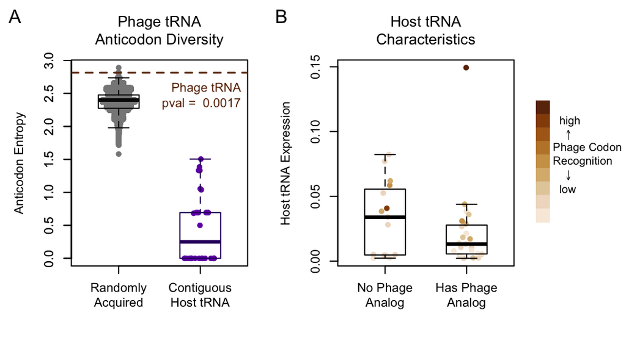

And what of the tRNAs that the phage does not carry? We found that the host expresses of many of these tRNAs more highly than the tRNAs with phage analogs (Figure 4.5B). Assuming similar rates of degradation for each tRNA, the more highly expressed tRNAs may persist longer during infection, thereby reducing the selective pressure for the phage to acquire its own copies. The tRNAs without phage analogs that are expressed lowly by the host recognize codons that are used very infrequently by the phage. These two types of tRNA may confer less of a selective advantage to the phage than the tRNA already present in the phage, implying that for these tRNAs the phage has reduced its dependence on their codons rather than acquire its own copies of the tRNAs. Taken together, the observations presented in this paper strongly imply that the primary function for phage tRNAs is to supplement degrading host translational machinery, which results from an all-destructive lytic infection phenotype.

# 5 Discussion

This simple line of logic unifies many observations previously made in the literature, either through deep interrogations of the T4 infection cycle or broad analyses of tRNA-carrying phage: First, the presence of many tRNAs is more often found in genomes of lytic phage than those of temperate phage (Bailly-Bechet, Vergassola, and Rocha 2007). Aggressively lytic phage often degrade the host genome as the phage can then use the nucleotides to increase its burst size. But because translation is required for phage particle production, these phage presumably benefit from shuttling their own translation machinery by extending the replication period beyond the time at which the host resources are depleted.

A second observation is that phage tRNAs appear to optimize codon usage bias toward phage genes and away from host genes (Scherberg and Weiss 1972). According to our findings, tRNAs absent from the phage correspond to those that tend to be more highly expressed in the host than tRNAs present in the phage, and tRNAs highly expressed in the host correspond to codons that are most commonly used by the host, or are most biased toward the host (Supplementary Figure 7). This backdoor correlation may explain a large part of the observed codon usage bias effect. Moreover, once the phage acquire tRNA, an adaptive feedback loop can form between the phage genome codon usage and the tRNA array that it carries. This feedback loop explains a third observation, which is that codon usage bias is more pronounced in late phage genes than in the early genes (Cowe and Sharp 1991; Kunisawa 1992; Kunisawa, Kanaya, and Kutter 1998). Early mRNAs require use of host tRNAs, as the bulk of phage tRNAs are still in the process of being transcribed and processed, whereas late mRNAs are expected to be more dependent on the phage tRNAs, as the bulk of the host tRNA might be degraded later in the infection.

And finally, a fourth observation is that phage with tRNAs generally have larger genomes than those without (Bailly-Bechet, Vergassola, and Rocha 2007). For phage with large genomes, it is more important to degrade the host genome to free up nucleotides, leading again to the quandary presented by the first point. In addition, larger phage might require longer periods of replication and more resources for supporting translation in the wake of degrading host tRNA. The longer the infection persists past host resource degradation, the stronger the selective pressure for phage to encode their own machinery, which in turn selects for larger phage. A tRNA deletion mutant of phage 2.275.O could address how tRNAs change the latent period or burst size during infection. We note that this experiment may prove very difficult to do in a wild, non-model system such as we utilize here and could potentially be carried out in a more tractable model system.

Using this lens, it is interesting to compare 2.275.O against its foil in the same phage sampling collection, the Autolykiviridae (Kauffman et al. 2018). In contrast with this 349kb phage, Autolykiviridae carry a particularly small, streamlined genome, at only 10kb. With such small genomes, there may be less selective pressure to free up the nucleotide pool. In fact, Autolykiviridae do not degrade the host genome. The infection cycle of these viruses can last on the order of weeks, and with only 20 genes in its genome, having no known translation supporting functions, they must rely entirely on the host translation machinery. Although a whole spectrum of strategies might co-exist, we can see here two extreme and contrasting strategies.

This type of phage infection might have convenient applications for studying tRNA regulation. Although translation is fundamental to all of life, many aspects are still unknown. For example, while some tRNA modifications have been shown to be necessary for correct folding, synthetase recognition, degradation, and translation regulation (Lorenz, Lünse, and Mörl 2017), the functions of most modifications are unknown (Kirchner and Ignatova 2015). Many recent findings about tRNA are conducted in systems in which a cellular stress response involving tRNA can be triggered (Kirchner and Ignatova 2015). Lytic phage infection offers a similar convenience in that it can be synchronized through a one-step-growth experiment (Ellis and Delbrück 1939). Because of this, tRNA can be “tracked” from the newly synthesized nascent form to processed intermediates and degraded products. In fact, this can be seen in our tRNA sequencing timecourse (Supplementary Figure 8-10). Exciting new technologies for probing translation now exist, such as ribosomal footprint profiling (Ingolia et al. 2009), tRNA-ribo-seq (Chen and Tanaka 2018). Work in combining these techniques with phage growth experiments may be a promising future direction for uncovering further insights into tRNA processing and use in translation.

# 6 Materials and Methods

The code and processed data used for this paper are available on Github (https://github.com/ratatstats/tRNAbias) in the form of an R (R Core Team 2018) package. The code used for the analyses and figures is available in */doc* as an rmarkdown file, and can be compiled and run as a vignette for the purpose of walking through the data and analysis details. Raw sequencing reads are available on the NCBI Sequenced Reads Archive under BioProject numbers PRJNA524872 (tRNA-seq) and PRJNA524877 (full transcriptome RNA-seq).

## 6.1 Exploratory genome-based codon usage bias analysis

In order to assess the plausibility of the codon usage bias hypothesis, we conducted a preliminary analysis of the phage and host genomes. The tRNA carried by each organism was called using tRNAscan-SE (Lowe and Eddy 1997) and Aragorn (Laslett and Canback 2004). The multidimensional scaling analysis uses Shannon-Jensen divergence between codon distributions for each protein as the distance metric. The odds ratio for each codon is defined as $\frac{P(\text{codon | org = phage})/(1-P(\text{codon | org = phage}))}{P(\text{codon | org = host})/(1-P(\text{codon | org = host}))}$.

## 6.2 tRNA sequencing timecourse

In order to explore the shift in tRNA abundance throughout the course of infection, we conducted a one-step-growth experiment and collected samples at 15 minute intervals. Cells from the same culture were split in two (control vs. infection) then centrifuged to pellets. The control sample was resuspended in 200 $\mu$L of Difco 2216 Marine Broth, and the infection sample was resuspended in 150$\mu$L 2216 and 50 $\mu$L of phage lysate. The samples were left to sit for 5 minutes to allow for adsorption of the phage, then diluted to a volume of 15 mL in order to deter further infection. This total volume was split in 5, one sample from each set was immediately centrifuged and flash frozen as a “time 0” sample, and the rest were placed on a shaker, then centrifuged down and flash frozen at 15 minute intervals. 500 $\mu$L aliquots were taken from each sample prior to centrifugation to be plated as a spot check of phage concentration. A schematic of this experiment is presented in Supplementary Figure 11, and the resulting plaque data is presented in Supplementary Figure 12.

## 6.3 RNA sequencing timecourse

To further hone in on particular genes that the codon usage bias may favor, a second phage growth experiment was collected for full-transcriptome RNA sequencing. In this experiment, an aliquot of a culture was centrifuged and flash frozen as a preinfection timepoint, the remainder of the culture was then centrifuged to a pellet then resuspended with 400 $\mu$L of a phage lysate. The samples were left to sit for 5 minutes to allow for adsorption of the phage, then diluted to a total volume of 45 mL in order to deter further infection. This total volume was split into 9 samples of 5 mL each, to be taken in 15 minute intervals from time 0 to 120 minutes. The sampling procedure involved flash freezing 3 pellets spun down from 1.5 mL aliquots of each sample, then immediately doing serial dilutions of unfiltered and filtered viruses to assess phage growth and stage of infection. A schematic of this experiment is presented in Supplementary Figure 13, and the resulting plaque data is presented in Supplementary Figure 14.

## 6.4 Total RNA extraction

Total RNA from the infection time series (flash-frozen pellets) was extracted by the hot phenol method. Briefly, cell pellets were resuspended in TE (10 mM Tris pH 7.0, 1 mM EDTA) and treated with 0.5 mg/ml lysozyme at room temperature for 5 minutes. Then NaOAc (100 mM final concentration) and SDS (1% final concentration) were added, followed by an equal volume of acid phenol:chloroform pH 4.5 (ThermoFisher). The mixture was shaken at 65°C for 10 minutes using a thermomixer, and centrifuged at 20000 x g for 5 minutes. The upper phase was washed by chloroform and centrifuged at 20000 x g for 5 minutes. The phenol/chloroform extraction was repeated once, and the upper phase was precipitated with isopropanol and 300 mM NaOAc. Precipitated RNA was washed with 75% ethanol, air dried and resuspended in water.

## 6.5 High-throughput sequencing of tRNAs

tRNAs were gel purified from total RNA on a 10% urea polyacrylamide gel (size selected between 70 and 100 nt). Gel pieces were macerated and soaked in 0.3 M NaCl overnight with rotation at 4°C for elution. tRNAs were precipitated with isopropanol using linear acrylamide as the carrier. RNA pellets were resuspended in 100 mM Tris-Cl pH 9.5 and incubated at 37°C for 1.5 hours for deacylation. After deacylation RNA was purified using Oligo Clean & Concentrator (Zymo Research) and eluted in 10 mM Tris pH 8.0. Purified RNA was ligated to a 3’ preadenylated adapter AppNNNNAGATCGGAAGAGCACACGTCT/iBiodT/iBiodT/3ddC/ (final concentration 10 uM) using RNL2 truncated KQ (NEB) with 10% PEG8000 at room temperature overnight. After ligation RNA was purified using the MinElute PCR Purification kit (Qiagen) and reverse transcribed using TGIRTTM-III enzyme (InGex) under manufacturer’s instructions. Briefly, RNA was incubated with an RT primer AGACGTGTGCTCTTCCGATCT (0.1 $\mu$M final concentration) and RT buffer at 85°C for 5 minutes, and cooled to 25°C at 0.1°C per second. DTT and TGIRTTM-III were added and the mixture was incubated at room temperature for 30 minutes. dNTPs were added and the reaction was incubated at 60°C for 30 minutes. RNA was hydrolyzed by NaOH, neutralized by HCl and purified using MinElute PCR purification kit. cDNA was ligated to a preadenylated DNA adapter AppNNNNGATCGTCGGACTGTAGAACTCTGA/3ddC/ (preadenylated by 5’ DNA adenylation kit (NEB)) using thermostable 5’ App DNA/RNA ligase (NEB) following manufacturer’s protocol (ligated at 65°C for 5 hours and heated inactivated at 90°C for 3 minutes). cDNA was purified using MinElute PCR purification kit, and amplified using KAPA HiFi HotStart PCR kit (Roche). PCR primers were AATGATACGGCGACCACCGAGATCTACACGTTCAGAGTTCTACAGTCCGACGATC and CAAGCAGAAGACGGCATACGAGATBBBBBBGTGACTGGAGTTCAGACGTGTGCTCTTCCGATCT (BBBBBB stands for barcode sequence). PCR products were size selected between 150 nt and 260 nt using Pippin Prep (Sage Science), and sequenced on an Illumina HiSeq under 100 bp by 100 bp paired-end mode.

## 6.6 Full transcriptiome RNA-seq

For quantitative RNA-seq, 1.5 ng Firefly luciferase mRNA and 0.015 ng of Renilla luciferase mRNA was added to each cell pellet before hot phenol extraction. As each sample was derived from the same infection batch, which was distributed in equal volumes, these two luciferase mRNA spike-ins are proportional to the starting quantity of infected cells. Total RNA was treated by TURBO DNase (ThermoFisher) according to manufacturer’s protocol and purified using RNA Clean & Concentrator kit (Zymo Research). mRNA was isolated using the Illumina Ribozero prokaryote kit (gram positive and negative, Illumina) and was prepared into libraries using the Kapa Hyperprep kit (Roche) following manufacturer’s protocols. Libraries were sequenced on an Illumina HiSeq under 40 bp single-end mode.

## 6.7 Calling modifications on tRNA sequencing data

For the dual purposes of 1. assessing whether the phage tRNA are functional tRNA that participate in translation and 2. more accurately assigning wobble base affinities, RNA modifications were called based on reverse transcriptase substitutions. First, a reference alignment of phage and host tRNA was made. LocaRNA (Will et al. 2007), which accounts for RNA secondary structure, was used to make a first-pass multiple alignment. Phage tRNA called with introns often aligned poorly, and so the alignments were fixed using the putative secondary structures provided by Aragorn. The variable loops were aligned separately using MUSCLE (Edgar 2004), then stitched back into the tRNA alignment. The final multiple alignment of the unique tRNA are shown in Supplementary Figure 15. Next, *E. coli* tRNA from the MODOMICS database (Dunin-Horkawicz et al. 2006; Boccaletto et al. 2018) were aligned to this reference in order to identify what types of post-transcriptional modifications may be present. Reads from tRNA sequencing were then aligned to this reference using the affine gap penalty method “gotoh” provided by the $align.seqs()$ function in mothur, version 1.34.4 (Schloss et al. 2009), with the following scoring: match=2, mismatch=0, gapopen=-5, gapextend=-1. Phage and host tRNA are sufficiently different such that reads can be mapped back to the originating organism (Supplementary Figure 15). And finally, the base distribution at each position was used to fit a model for how modifications correspond to “missequenced” reads (as many of these are likely the result of base substitutions inserted by the reverse transcriptase upon encountering a modified base). A summary of base calls for each tRNA is provided in the Supplementary Materials.

## 6.8 Calculating phage RNA expression timing

Instead of classifying phage genes into distinct categories of expression timing, continuous scales were defined. Because the host RNA expression level climbs until 75 minutes, this is taken to be the timepoint before the second round of infections begin. In order to get a sense of transcription and degradation for the purposes of the analyses presented in Figure 4.2, the phage RNA expression timing was then defined as the center of mass of the expression levels over time. Each RNA is color coded by its expression timing in Supplementary Figure 17. However, for the purposes of visually identifying what may be transcriptional units within the genome (Figure 4.1, Supplementary Figure 1), another measure of expression timing - the time taken to reach half the maximum level of expression - was defined. Each RNA is color coded by its expression timing in Supplementary Figure 18.

## 6.9 Assessing Genome Degradation

Two genes were selected for qPCR to assess whether the host genome is degraded upon infection: GroEL (Genbank locus tag BCV12_01410, primers: CAATGGATCTTAAGCGCGGC and CAGAGATAACCGTACCGCCC) and CTP synthetase (Genbank locus tag BCV12_03025, primers: CTTTGGCGATCGTGGTGTTG and TTTTCTAATTCGCCGCGCTG). The phage genes, GroEL (Genbank locus tag NVP2275O_355, primers: CTTTGAAGACATGGGCGCAC and AACGACTAGGGTTGCAAGCA) and the Major Capsid Protein (Genbank locus tag NVP2275O_445, primers: TGAAGGTGTTATGGGTCGCC and ATACGGGCAGTAGAACGCAG), was also assayed for contrast. Each sample was prepared using the Kapa SYBER Fast kit according to the manufacturer’s instructions. A standard curve for each primer was made on 10 two-fold serial dilutions of each genome. This was then used to convert the CT values to copy number.

## 6.10 Codon Usage Bias Analysis

In order to assess whether the phage tRNA pool may introduce translational bias toward its own genes, a summary statistic for each gene that represents the efficiency with which it can be translated by the phage tRNA pool, relative to the efficiency with which it can be translated by the host tRNA pool was calculated. This value, essentially a likelihood ratio, is referred to as the “slant” of a gene for brevity. The calculation is as follows:

To set up the analysis, the codon usage preference of a tRNA pool must first be calculated. In particular, it is defined as an estimated probability of a random codon being bound given the tRNA pool:

$$\begin{align*}
P(\text{codon} | \text{pool = host}) &= \sum_x P(\text{codon}, \text{tRNA} = x | \text{pool} = \text{host})\\
&= \sum_x P(\text{codon} | \text{tRNA} = x, \text{pool} = \text{host}) P(\text{tRNA} = x | \text{pool} = \text{host}) \\
&= \sum_x P(\text{codon} | \text{tRNA} = x) P(\text{tRNA} = x | \text{pool} = \text{host})
\end{align*}$$

Here, $P(\text{tRNA} = x | \text{pool} = \text{host})$ is defined as the read abundances from tRNA sequencing, normalized to each organism. $P(\text{codon} | \text{tRNA} = x)$ is defined according to revised wobble rules noted by Murphy, et al. (Murphy and Ramakrishnan 2004; Watanabe and Osawa 1995; Yokoyama and Nishimura 1995), accounting for wobble base modifications inferred through tRNA sequencing results. Low affinity pairings receive a third the weight of high affinity parings.

These two points define a path that the codon distribution for each protein can, essentially, be projected upon in order to calculate a tRNA pool preference for each protein (here, referred to in short as the “slant”). Specifically, for each protein, the slant for a given gene with codon counts $y$, is calculated as the log likelihood ratio of observing the codons from that gene given the coding capacity of the phage tRNA pool vs. given the coding capacity of the host tRNA pool (divided by the total number of codons, to make the value more easily comparable among proteins):

$$\begin{align*}
\frac{1}{n}\Lambda(y) &= \frac{1}{n} log \left( \frac{\frac{n!}{y_1! ... y_k!}p_1^{y_1} ... p_k^{y_k}}{\frac{n!}{y_1! ... y_k!}h_1^{y_1} ... h_k^{y_k}} \right) \\
&= \frac{1}{n} \sum_{\text{codons }c} y_c log \frac{p_c}{h_c}
\end{align*}$$

## 6.11 Assessing the statistical significance of codon usage bias

A one-sided Kolmogorov-Smirnov test was used to assess the difference in distributions of slant values for phage genes vs. slant values for host genes. This resulted in a suspiciously low p-value (less than 1e-22), which was taken as a signal that the null model used may not have been fair in the context of this problem, and more relevant assumptions should be specified. In this case, we already know from preliminary analyses that the distributions of codon usage between phage and host genes is different (Figures 2C and 4B), so any randomly chosen vector of phage tRNA expression is likely to betray this difference.

Instead, it is more appropriate to ask whether the slant values for phage genes vs. the slant values for host genes are different *conditioning on the known codon usage distribution of the two organisms*. This was done using the following resampling scheme: First, 18 tRNA (the number of phage tRNA) are randomly sampled with replacement from the host genome, then a random expression vector for these 18 tRNA was generated by normalizing exponentially distributed random variables. This expression vector was used as a random phage tRNA expression vector. Then, based on this random phage tRNA expression vector and the known host tRNA expression vector, slant values were calculated for phage and host genes, and a one-sided KS-test was conducted on these slant values. This procedure was replicated 200 times, and these test results formed the null distribution against which the original test result was compared.

# 7 Acknowledgements

We thank Uttam RajBhandary for poring over the tRNA structures with us and for pointing us toward relevant literature. We would additionally like to thank Jan-Christian Hütter for thoughtful discussion and comments about the analysis methods. J. Y. Yang was supported by the Department of Energy Computational Science Graduate Fellowship Program of the Office of Science and National Nuclear Security Administration in the Department of Energy under contract DE-FG02-97ER25308. This work was supported by grants from the National Science Foundation OCE 1435993 and 1435868 to M.P. and L.K., respectively. L. K. is supported in part by a Peer Reviewed Cancer Research Program Career Development Award from the United States Department of Defense (CA171019).

# References

Abergel, Chantal, Matthieu Legendre, and Jean-Michel Claverie. 2015. “The rapidly expanding universe of giant viruses: Mimivirus, Pandoravirus, Pithovirus and Mollivirus.” Edited by Alain Filloux. *FEMS Microbiology Reviews* 39 (6): 779–96. https://doi.org/10.1093/femsre/fuv037.

Amitsur, M, R Levitz, and G Kaufmann. 1987. “Bacteriophage T4 anticodon nuclease, polynucleotide kinase and RNA ligase reprocess the host lysine tRNA.” *The EMBO Journal* 6 (8): 2499–2503. [http://www.pubmedcentral.nih.gov/articlerender.fcgi?artid=553660{\&}tool=pmcentrez{\&}rendertype=abstract](http://www.pubmedcentral.nih.gov/articlerender.fcgi?artid=553660%7B\&%7Dtool=pmcentrez%7B\&%7Drendertype=abstract).

Bailly-Bechet, Marc, Massimo Vergassola, and Eduardo Rocha. 2007. “Causes for the intriguing presence of tRNAs in phages.” *Genome Research* 17 (10): 1486–95. https://doi.org/10.1101/gr.6649807.

Boccaletto, Pietro, Magdalena A Machnicka, Elzbieta Purta, Paweł Pia̧tkowski, Błażej Bagiński, Tomasz K Wirecki, Valérie de Crécy-Lagard, et al. 2018. “MODOMICS: a database of RNA modification pathways. 2017 update.” *Nucleic Acids Research* 46 (D1): D303–D307. https://doi.org/10.1093/nar/gkx1030.

Botzman, Maya, and Hanah Margalit. 2011. “Variation in global codon usage bias among prokaryotic organisms is associated with their lifestyles.” *Genome Biology* 12 (10): R109. https://doi.org/10.1186/gb-2011-12-10-r109.

Chen, Chien-Wen, and Motomasa Tanaka. 2018. “Genome-wide Translation Profiling by Ribosome-Bound tRNA Capture.” *Cell Reports* 23 (2): 608–21. https://doi.org/10.1016/j.celrep.2018.03.035.

Clark, Wesley C., Molly E. Evans, Dan Dominissini, Guanqun Zheng, and Tao Pan. 2016. “tRNA base methylation identification and quantification via high-throughput sequencing.” *RNA* 22 (11): 1771–84. https://doi.org/10.1261/rna.056531.116.

Cowe, Elizabeth, and Paul M. Sharp. 1991. “Molecular evolution of bacteriophages: Discrete patterns of codon usage in T4 genes are related to the time of gene expression.” *Journal of Molecular Evolution* 33 (1): 13–22. https://doi.org/10.1007/BF02100191.

Daniel, V., S. Sarid, and U. Z. Littauer. 1968. “Amino acid acceptor activity of bacteriophage T4 transfer RNA.” *FEBS Letters* 2 (1): 39–41. https://doi.org/10.1016/0014-5793(68)80095-X.

Davis, B D, S M Luger, and P C Tai. 1986. “Role of ribosome degradation in the death of starved Escherichia coli cells.” *Journal of Bacteriology* 166 (2): 439–45. [http://www.ncbi.nlm.nih.gov/pubmed/2422153 http://www.pubmedcentral.nih.gov/articlerender.fcgi?artid=PMC214624](http://www.ncbi.nlm.nih.gov/pubmed/2422153%20http://www.pubmedcentral.nih.gov/articlerender.fcgi?artid=PMC214624).

Delesalle, Véronique A., Natalie T. Tanke, Albert C. Vill, and Greg P. Krukonis. 2016. “Testing hypotheses for the presence of tRNA genes in mycobacteriophage genomes.” *Bacteriophage* 6 (3): e1219441. https://doi.org/10.1080/21597081.2016.1219441.

Dunin-Horkawicz, S., Anna Czerwoniec, Michal J. Gajda, Marcin Feder, Henri Grosjean, and Janusz M. Bujnicki. 2006. “MODOMICS: a database of RNA modification pathways.” *Nucleic Acids Research* 34 (90001): D145–D149. https://doi.org/10.1093/nar/gkj084.

Dupasquier, Marcel, Sangbumn Kim, Konstantine Halkidis, Howard Gamper, and Ya-Ming Hou. 2008. “tRNA integrity is a prerequisite for rapid CCA addition: implication for quality control.” *Journal of Molecular Biology* 379 (3): 579–88. https://doi.org/10.1016/j.jmb.2008.04.005.

Edgar, Robert C. 2004. “MUSCLE: multiple sequence alignment with high accuracy and high throughput.” *Nucleic Acids Research* 32 (5): 1792–7. https://doi.org/10.1093/nar/gkh340.

Ellis, E L, and M Delbrück. 1939. “THE GROWTH OF BACTERIOPHAGE.” *The Journal of General Physiology* 22 (3): 365–84. https://doi.org/10.1085/JGP.22.3.365.

Enav, Hagay, Oded Béjà, and Yael Mandel-Gutfreund. 2012. “Cyanophage tRNAs may have a role in cross-infectivity of oceanic Prochlorococcus and Synechococcus hosts.” *The ISME Journal* 6 (3): 619–28. https://doi.org/10.1038/ismej.2011.146.

Grantham, R, C Gautier, M Gouy, R Mercier, and A Pavé. 1980. “Codon catalog usage and the genome hypothesis.” *Nucleic Acids Research* 8 (1): r49–r62. [http://www.ncbi.nlm.nih.gov/pubmed/6986610 http://www.pubmedcentral.nih.gov/articlerender.fcgi?artid=PMC327256](http://www.ncbi.nlm.nih.gov/pubmed/6986610%20http://www.pubmedcentral.nih.gov/articlerender.fcgi?artid=PMC327256).

Harada, Fumio, and Susumu Nishimura. 1974. “Purification and characterization of AUA specific isoleucine transfer ribonucleic acid from Escherichia coli B.” *Biochemistry* 13 (2): 300–307. https://doi.org/10.1021/bi00699a011.

Hatfull, Graham F. 2008. “Bacteriophage genomics.” *Current Opinion in Microbiology* 11 (5): 447–53. https://doi.org/10.1016/j.mib.2008.09.004.

Hou, Ya-Ming. 2010. “CCA addition to tRNA: implications for tRNA quality control.” *IUBMB Life* 62 (4): 251–60. https://doi.org/10.1002/iub.301.

Ikemura, Toshimichi. 1981. “Correlation between the abundance of Escherichia coli transfer RNAs and the occurrence of the respective codons in its protein genes: A proposal for a synonymous codon choice that is optimal for the E. coli translational system.” *Journal of Molecular Biology* 151 (3): 389–409. https://doi.org/10.1016/0022-2836(81)90003-6.

Ingolia, Nicholas T., Sina Ghaemmaghami, John R. S. Newman, and Jonathan S. Weissman. 2009. “Genome-Wide Analysis in Vivo of Translation with Nucleotide Resolution Using Ribosome Profiling.” *Science* 324 (5924): 218–23. https://doi.org/10.1126/SCIENCE.1168978.

Kauffman, Anne Kathryn Marie. 2014. “Demographics of lytic viral infection of coastal ocean vibrio.” Massachusetts Institute of Technology. http://dspace.mit.edu/handle/1721.1/90046.

Kauffman, Kathryn M., Fatima A. Hussain, Joy Yang, Philip Arevalo, Julia M. Brown, William K. Chang, David VanInsberghe, et al. 2018. “A major lineage of non-tailed dsDNA viruses as unrecognized killers of marine bacteria.” *Nature* 554 (7690): 118–22. https://doi.org/10.1038/nature25474.

Kirchner, Sebastian, and Zoya Ignatova. 2015. “Emerging roles of tRNA in adaptive translation, signalling dynamics and disease.” *Nature Reviews Genetics* 16 (2): 98–112. https://doi.org/10.1038/nrg3861.

Korostelev, Andrei, Sergei Trakhanov, Martin Laurberg, and Harry F. Noller. 2006. “Crystal Structure of a 70S Ribosome-tRNA Complex Reveals Functional Interactions and Rearrangements.” *Cell* 126 (6): 1065–77. https://doi.org/10.1016/j.cell.2006.08.032.

Kunisawa, T. 1992. “Synonymous codon preferences in bacteriophage T4: a distinctive use of transfer RNAs from T4 and from its host Escherichia coli.” *Journal of Theoretical Biology* 159 (3): 287–98. http://www.ncbi.nlm.nih.gov/pubmed/1296091.

Kunisawa, T, S Kanaya, and E Kutter. 1998. “Comparison of synonymous codon distribution patterns of bacteriophage and host genomes.” *DNA Research : An International Journal for Rapid Publication of Reports on Genes and Genomes* 5 (6): 319–26. http://www.ncbi.nlm.nih.gov/pubmed/10048480.

La Scola, B, S Audic, C Robert, …L Jungang -, and Undefined 2003. 2003. “A giant virus in amoebae.” *Science.sciencemag.org* 299 (5615): 2033. [http://science.sciencemag.org/content/299/5615/2033.short?casa{\_}token=Nq2f311WOP4AAAAA:-cTJssOLovjGxZ2PUderbXRd{\_}AOwD03S9kaX-OcIKEbiJO5xbXZNjY2e7{\_}vqQL7ovExSNkYXn0nhHw](http://science.sciencemag.org/content/299/5615/2033.short?casa%7B\_%7Dtoken=Nq2f311WOP4AAAAA:-cTJssOLovjGxZ2PUderbXRd%7B\_%7DAOwD03S9kaX-OcIKEbiJO5xbXZNjY2e7%7B\_%7DvqQL7ovExSNkYXn0nhHw).

Laslett, Dean, and Bjorn Canback. 2004. “ARAGORN, a program to detect tRNA genes and tmRNA genes in nucleotide sequences.” *Nucleic Acids Research* 32 (1): 11–16. https://doi.org/10.1093/nar/gkh152.

Lorenz, Christian, Christina E Lünse, and Mario Mörl. 2017. “tRNA Modifications: Impact on Structure and Thermal Adaptation.” *Biomolecules* 7 (2). https://doi.org/10.3390/biom7020035.

Lowe, T M, and S R Eddy. 1997. “tRNAscan-SE: a program for improved detection of transfer RNA genes in genomic sequence.” *Nucleic Acids Research* 25 (5): 955–64. [http://www.ncbi.nlm.nih.gov/pubmed/9023104 http://www.pubmedcentral.nih.gov/articlerender.fcgi?artid=PMC146525](http://www.ncbi.nlm.nih.gov/pubmed/9023104%20http://www.pubmedcentral.nih.gov/articlerender.fcgi?artid=PMC146525).

Matsuzaki, Shigenobu, Shuji Tanaka, Tetsuro Koga, and Tomio Kawata. 1992. “A Broad-Host-Range Vibriophage, KVP40, Isolated from Sea Water.” *Microbiology and Immunology* 36 (1): 93–97. https://doi.org/10.1111/j.1348-0421.1992.tb01645.x.

Miller, Eric S, John F Heidelberg, Jonathan A Eisen, William C Nelson, A Scott Durkin, Ann Ciecko, Tamara V Feldblyum, et al. 2003. “Complete genome sequence of the broad-host-range vibriophage KVP40: comparative genomics of a T4-related bacteriophage.” *Journal of Bacteriology* 185 (17): 5220–33. [http://www.pubmedcentral.nih.gov/articlerender.fcgi?artid=180978{\&}tool=pmcentrez{\&}rendertype=abstract](http://www.pubmedcentral.nih.gov/articlerender.fcgi?artid=180978%7B\&%7Dtool=pmcentrez%7B\&%7Drendertype=abstract).

Murphy, Frank V, and V Ramakrishnan. 2004. “Structure of a purine-purine wobble base pair in the decoding center of the ribosome.” *Nature Structural & Molecular Biology* 11 (12): 1251–2. https://doi.org/10.1038/nsmb866.

Raoult, Didier, Stéphane Audic, Catherine Robert, Chantal Abergel, Patricia Renesto, Hiroyuki Ogata, Bernard La Scola, Marie Suzan, and Jean-Michel Claverie. 2004. “The 1.2-megabase genome sequence of Mimivirus.” *Science (New York, N.Y.)* 306 (5700): 1344–50. https://doi.org/10.1126/science.1101485.

R Core Team. 2018. *R: A Language and Environment for Statistical Computing*. Vienna, Austria: R Foundation for Statistical Computing. https://www.R-project.org/.

Reis, Mario dos, Renos Savva, and Lorenz Wernisch. 2004. “Solving the riddle of codon usage preferences: a test for translational selection.” *Nucleic Acids Research* 32 (17): 5036–44. https://doi.org/10.1093/nar/gkh834.

Scherberg, N H, and S B Weiss. 1972. “T4 transfer RNAs: codon recognition and translational properties.” *Proceedings of the National Academy of Sciences of the United States of America* 69 (5): 1114–8. https://doi.org/10.1073/PNAS.69.5.1114.

Schloss, Patrick D, Sarah L Westcott, Thomas Ryabin, Justine R Hall, Martin Hartmann, Emily B Hollister, Ryan A Lesniewski, et al. 2009. “Introducing mothur: open-source, platform-independent, community-supported software for describing and comparing microbial communities.” *Applied and Environmental Microbiology* 75 (23): 7537–41. https://doi.org/10.1128/AEM.01541-09.

Schulz, Frederik, Natalya Yutin, Natalia N Ivanova, Davi R Ortega, Tae Kwon Lee, Julia Vierheilig, Holger Daims, et al. 2017. “Giant viruses with an expanded complement of translation system components.” *Science (New York, N.Y.)* 356 (6333): 82–85. https://doi.org/10.1126/science.aal4657.

Sharp, Paul M, Laura R Emery, and Kai Zeng. 2010. “Forces that influence the evolution of codon bias.” *Philosophical Transactions of the Royal Society of London. Series B, Biological Sciences* 365 (1544): 1203–12. https://doi.org/10.1098/rstb.2009.0305.

Svenningsen, Sine Lo, Mette Kongstad, Thomas Søndergaard Stenum, Ana J Muñoz-Gómez, and Michael A Sørensen. 2017. “Transfer RNA is highly unstable during early amino acid starvation in Escherichia coli.” *Nucleic Acids Research* 45 (2): 793–804. https://doi.org/10.1093/nar/gkw1169.

Watanabe, Kimitsuna, and Syozo Osawa. 1995. “tRNA sequences and variation in the genetic code.” In *TRNA: Structure, Biosynthesis, and Function*, edited by Dieter Söll and Uttam Rajbhandary, 225–50. Washington, DC: ASM Press.

Weiss, S B, W T Hsu, J W Foft, and N H Scherberg. 1968. “Transfer RNA coded by the T4 bacteriophage genome.” *Proceedings of the National Academy of Sciences of the United States of America* 61 (1): 114–21. [http://www.ncbi.nlm.nih.gov/pubmed/4880604 http://www.pubmedcentral.nih.gov/articlerender.fcgi?artid=PMC285912](http://www.ncbi.nlm.nih.gov/pubmed/4880604%20http://www.pubmedcentral.nih.gov/articlerender.fcgi?artid=PMC285912).

Will, Sebastian, Kristin Reiche, Ivo L. Hofacker, Peter F. Stadler, and Rolf Backofen. 2007. “Inferring Noncoding RNA Families and Classes by Means of Genome-Scale Structure-Based Clustering.” *PLoS Computational Biology* 3 (4): e65. https://doi.org/10.1371/journal.pcbi.0030065.

Wilson, John H. 1973. “Function of the bacteriophage T4 transfer RNA’s.” *Journal of Molecular Biology* 74 (4): 753–57. https://doi.org/10.1016/0022-2836(73)90065-X.

Yokoyama, Shigeyuki, and Susumu Nishimura. 1995. “Modified nucleosides and codon recognition.” In *TRNA: Structure, Biosynthesis, and Function*, edited by Dieter Söll and Uttam L. RajBhandary, 207–23. Washington, DC: ASM Press.

Zhong, Jiayong, Chuanle Xiao, Wei Gu, Gaofei Du, Xuesong Sun, Qing-Yu He, and Gong Zhang. 2015. “Transfer RNAs Mediate the Rapid Adaptation of Escherichia coli to Oxidative Stress.” Edited by Michael Ibba. *PLOS Genetics* 11 (6): e1005302. https://doi.org/10.1371/journal.pgen.1005302.